# Loading and preprocessing the data

## Loading and preprocessing the data

This code loads the raw CSV data into a data frame, converts the date fields to the Date class, and creates a second data frame with the rows that have NA in the “steps” column removed. We will need this processed data for some applications.

```r
activity <- read.csv("activity.csv")
activity$date<-as.Date(activity$date)
activity.no.na <- activity[!is.na(activity$steps),]
```

## What is mean total number of steps taken per day?

We start by computing the steps totals by day, and determining the mean and median. Then we plot the distribution of the daily totals as a histogram, along with a line indicating the mean.

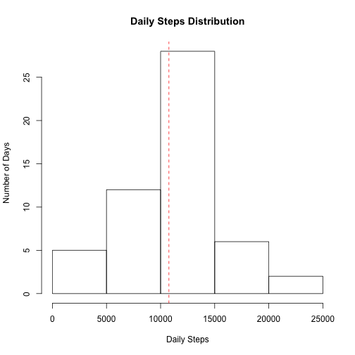

```r
daily.totals <- tapply(activity.no.na$steps,activity.no.na$date,sum)
daily.mean <- mean(daily.totals)
daily.median <- median(daily.totals)

hist(daily.totals, xlab="Daily Steps", ylab="Number of Days", main="Daily Steps Distribution")
abline(v=daily.mean,col="red",lty=2)
```

**Mean**: 10766.19  
**Median**: 10765

The mean and median are almost identical for this distribution. The histogram shows that on a typical day, this person makes between 10,000 and 15,000 steps – this range has by far the highest frequency. The red line on the histogram represents the mean.

## What is the average daily activity pattern?

We compute the average number of steps for each interval across all days, then make a time-series plot of that data. Then we get the interval with the maximum number of steps, and add a line to the plot indicating this.

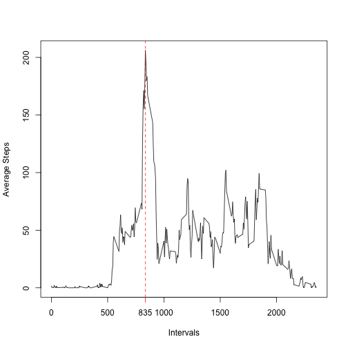

```r
interval.means <- tapply(activity.no.na$steps,activity.no.na$interval,mean)
plot(as.numeric(names(interval.means)),interval.means,type="l",xlab="Intervals",ylab="Average Steps")

max.interval <- as.numeric(names(interval.means[interval.means==max(interval.means)]))
abline(v=max.interval, col="red", lty=2)
axis(1, at=835, col="red")
```

The **835 interval** contains the **maximum** number of steps, on average.

## Imputing missing values

Let's begin by computing the number of missing values in the dataset.

```r
total.missing <- sum(is.na(activity$steps))
```

There are **2304 missing values**. Let's use interval means to fill these missing values. The code below builds a new dataset where missing values are filled in this way.

```r
activity2 <- activity
for (i in 1:nrow(activity2)) {
    if (is.na(activity2$steps[i])) {
      activity2$steps[i] <- interval.means[as.numeric(names(interval.means))==activity2$interval[i]]
    }
}
```

Now let's recreate the steps histogram and recompute the mean and median using this new dataset.

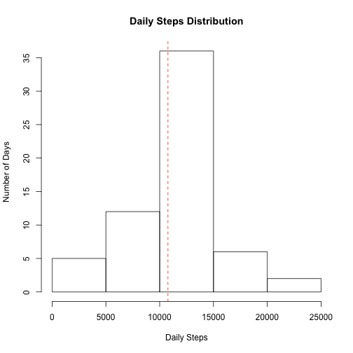

```r
daily.totals2 <- tapply(activity2$steps,activity2$date,sum)
daily.mean2 <- mean(daily.totals2)
daily.median2 <- median(daily.totals2)

hist(daily.totals2, xlab="Daily Steps", ylab="Number of Days", main="Daily Steps Distribution")
abline(v=daily.mean2, col="red", lty=2)
```

**Mean**: 10766.19  
**Median**: 10766.19

The mean remains the same as before, and the median is now equal to the mean. This makes sense, because the NA values were for several full days (i.e. every interval in these days is NA). This means that the total steps for each of those days would be equal to the daily mean, given the nature of our transformation. Adding several values to a dataset that are exactly equal to that dataset's mean will not alter the mean.

## Are there differences in activity patterns between weekdays and weekends?

We start by adding a new factor variable that indicates whether a given date is a weekday or a weekend.

```r
wd<-weekdays(activity2$date)
for (i in 1:length(wd)) {
    if (wd[i] == "Sunday" | wd[i] == "Saturday") {activity2$day[i] = "weekend"}
    else {activity2$day[i] = "weekday"}
}
activity2$day <- as.factor(activity2$day)
```

Now let's see if the weekday vs weekend activity patterns look different by plotting them side by side, with the same y-axis limits. We also compute the daily means for weekdays vs weekends.

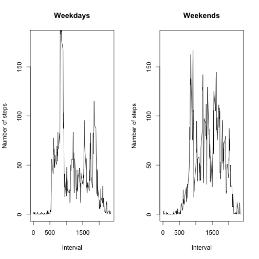

```r
week.days <- activity2[activity2$day == "weekday",]
week.ends <- activity2[activity2$day == "weekend",]
weekday.interval.means <- tapply(week.days$steps,week.days$interval,mean)
weekend.interval.means <- tapply(week.ends$steps,week.ends$interval,mean)

par(mfrow=c(1,2))
plot(as.numeric(names(weekday.interval.means)),weekday.interval.means,type="l",xlab="Interval",ylab="Number of steps",ylim=c(0,180), main="Weekdays")

plot(as.numeric(names(weekend.interval.means)),weekend.interval.means,type="l",xlab="Interval",ylab="Number of steps",ylim=c(0,180), main="Weekends")
```

```r
weekday.totals <- tapply(week.days$steps,week.days$date,sum)
weekday.mean <- mean(weekday.totals)
weekend.totals <- tapply(week.ends$steps,week.ends$date,sum)
weekend.mean <- mean(weekend.totals)
```

The plots seem to indicate more activity on weekends on average (though the peak activity interval is higher on weekdays). This is confirmed by looking at the daily means for weekdays vs weekends. For weekdays, the mean is **10255.85**, while for weekends it is **12201.52**.